# Project 2: Modeling, Testing, and Predicting

## Randomization Test

```r
#Test statistic calculation
yes<-guns%>%filter(law=="yes")
no<-guns%>%filter(law=="no")
mean(no$violent)-mean(yes$violent)
```

```
## [1] 161.1868
```

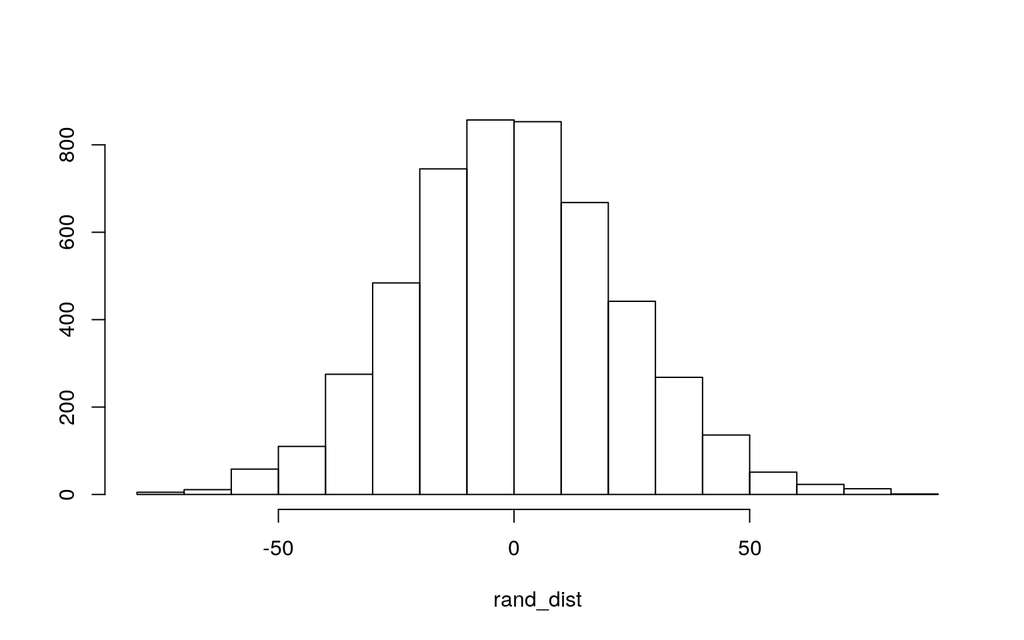

```r
#Randomizing data
rand_dist<-vector()
for(i in 1:5000){
new<-data.frame(violent=sample(guns$violent),condition=guns$law)
rand_dist[i]<-mean(new[new$condition=="yes",]$violent)-
mean(new[new$condition=="no",]$violent)}
hist(rand_dist,main="",ylab="");abline(v=-161.1868,col="red")
```

```r
#Calculating P-value
mean(rand_dist>161.1868)*2
```

```
## [1] 0
```

The test’s null hypothesis states that the difference between mean violent crime in areas with gun laws and areas without gun laws is zero or insignificant. THe alternative hypothesis is that there is a significant difference. The mean difference between the samples of violent crime rates between the two groups yielded a value of 161.1868. After conducting the test on this value, it was deemed that this value was significant as the p-value was found to be 0. This is further evidenced by the fact that the red line does not even show up on the histogram. As a result, it is reasonable to reject the null hypothesis and accept the alternative hypothesis. Therefore we can state that the difference in mean violence rate between states possessing gun control laws and states that do not possess gun control laws is not a zero value.

## Linear Regression

```r
#predicting violence rate based off income, male, and murder rate.
guns$c_income<-guns$income-mean(guns$income)
guns$c_male<-guns$male-mean(guns$male)
guns$c_murder<-guns$murder-mean(guns$murder)
fit<-lm(violent~c_income*c_male*c_murder,data=guns);summary(fit)
```

```
##
## Call:
## lm(formula = violent ~ c_income * c_male * c_murder,
data = guns)
##
## Residuals:
## Min 1Q Median 3Q Max
## -617.87 -89.70 -9.71 81.90 722.37
##
## Coefficients:
## Estimate Std. Error t value Pr(>|t|)
## (Intercept) 5.343e+02 5.074e+00 105.285 < 2e-16 ***
## c_income 3.105e-02 2.139e-03 14.519 < 2e-16 ***
## c_male -2.235e+01 3.066e+00 -7.288 5.77e-13 ***
## c_murder 5.213e+01 1.098e+00 47.491 < 2e-16 ***
## c_income:c_male 4.202e-03 9.373e-04 4.483 8.07e-06 ***
## c_income:c_murder -3.807e-03 2.547e-04 -14.946 < 2e-16
***
## c_male:c_murder -7.663e+00 6.826e-01 -11.227 < 2e-16 ***
## c_income:c_male:c_murder 6.116e-04 9.495e-05 6.442
1.72e-10 ***
## ---
## Signif. codes: 0 '***' 0.001 '**' 0.01 '*' 0.05 '.' 0.1
' ' 1
##
## Residual standard error: 148.9 on 1165 degrees of
freedom
## Multiple R-squared: 0.8028, Adjusted R-squared: 0.8016
## F-statistic: 677.6 on 7 and 1165 DF, p-value: < 2.2e-16
```

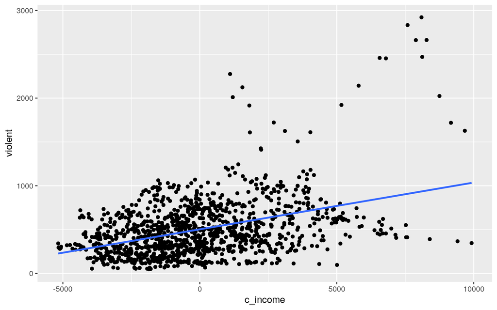

```r
#Plotting linear regression
guns%>%ggplot(aes(c_income,violent))+
geom_point()+
geom_smooth(method='lm',se=F)
```

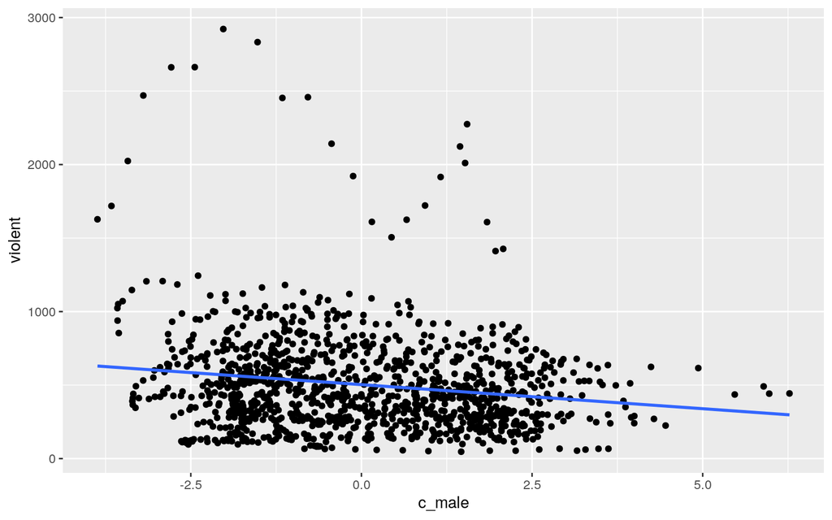

```r
guns%>%ggplot(aes(c_male,violent))+
geom_point()+
geom_smooth(method='lm',se=F)
```

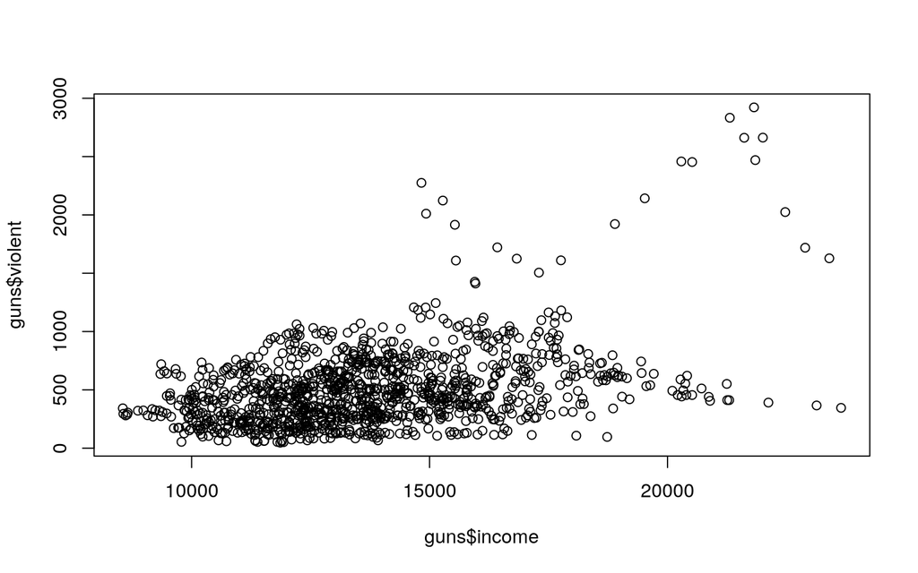

```r
plot(guns$income,guns$violent)
```